# NIAID-1468 | Answers to the Rpl/Rps questions

Short, plot-based response to colleague

This report uses **existing Step 3 CSV exports**; it does not rerun Seurat or GSEA. Each question has a plot and a short answer. A dot is a mouse unless otherwise indicated.

```r
suppressPackageStartupMessages({
  library(dplyr); library(tidyr); library(ggplot2); library(knitr)
})
P <- params
dir.create(P$output_dir, recursive=TRUE, showWarnings=FALSE)
# Locate previously generated Step 3 CSVs without recomputing the analysis.
# For a custom location, set params$step3_dir to the directory holding the exports.
required_step3_files <- c(
  "mouse_metadata.csv", "ribosomal_QC_by_mouse_subtype.csv",
  "ribosomal_QC_by_mouse_all_EC.csv",
  "top_rpl_rps_gene_mouse_subtype_CPM.csv",
  "GSEA_leading_edge_ribosomal_audit_significant.csv"
)
root <- normalizePath(P$step3_dir, mustWork=FALSE)
search_roots <- unique(c(root, getwd(), dirname(getwd()),
                         file.path(getwd(), "06_ribosomal_audit"),
                         file.path(getwd(), "06_ribosomal_audit_v2"),
                         file.path(getwd(), "step3"),
                         file.path(getwd(), "outputs"),
                         file.path(getwd(), "results")))
# Search only existing folders, with bounded recursion; no raw-data reprocessing.
candidate_dirs <- unique(unlist(lapply(search_roots, function(d) {
  if (!dir.exists(d)) return(character())
  hits <- list.files(d, pattern="^mouse_metadata\\.csv$", recursive=TRUE,
                     full.names=TRUE)
  c(d, dirname(hits))
}), use.names=FALSE))
valid_dirs <- candidate_dirs[vapply(candidate_dirs, function(d)
  all(file.exists(file.path(d, required_step3_files))), logical(1))]
if (!length(valid_dirs)) {
  stop(paste0(
    "Could not locate the previously exported Step 3 CSV files.\n",
    "Set step3_dir to the folder containing mouse_metadata.csv and the other four Step 3 CSVs.\n",
    "For example: quarto render NIAID1468_colleague_ribosomal_results_v3.qmd ",
    "-P step3_dir:/absolute/path/to/your/step3/exports\n",
    "Searched from: ", paste(search_roots, collapse=", ")
  ))
}
P$step3_dir <- normalizePath(valid_dirs[1], mustWork=TRUE)
cat("Reading existing Step 3 exports from:", P$step3_dir, "\n")
```

```
Reading existing Step 3 exports from: /vf/users/cheungf/NIAID-1468-colitis/NIAID-1468/cellseek_execution/seurat/analysis/06_ribosomal_audit
```

```r
read_step3 <- function(file, required=TRUE) {
  path <- file.path(P$step3_dir, file)
  if (!file.exists(path)) {
    if (required) stop("Required Step 3 export missing: ", path)
    return(NULL)
  }
  read.csv(path, stringsAsFactors=FALSE, check.names=FALSE)
}
save_csv <- function(x, file) write.csv(as.data.frame(x),
  file.path(P$output_dir,file), row.names=FALSE, na="")
show <- function(x,n=20) knitr::kable(utils::head(as.data.frame(x),n), digits=4)
pct <- function(x) paste0(round(100*x,2),"%")
mouse_map <- read_step3("mouse_metadata.csv")
ms <- read_step3("ribosomal_QC_by_mouse_subtype.csv")
ma <- read_step3("ribosomal_QC_by_mouse_all_EC.csv")
gx <- read_step3("top_rpl_rps_gene_mouse_subtype_CPM.csv")
gs <- read_step3("GSEA_leading_edge_ribosomal_audit_significant.csv")
rec <- read_step3("GSEA_leading_edge_gene_recurrence.csv",FALSE)
cor_old <- read_step3("QC_ribosomal_descriptive_correlations.csv",FALSE)
needed <- list(mouse_map=c("mouse_id","library_id","DSS_day"),
  ms=c("mouse_id","library_id","DSS_day","EC_subtype","n_cells","ribo_fraction_pooled",
       "mt_fraction_pooled","median_nUMI","median_nGene"),
  ma=c("mouse_id","library_id","DSS_day","ribo_fraction_pooled","mt_fraction_pooled"),
  gx=c("gene","mouse_id","EC_subtype","CPM","library_id","DSS_day"),
  gs=c("database","subtype","contrast","pathway","NES","padj",
       "n_leading","n_ribo","n_nonribo","ribo_leading_fraction",
       "ribo_genes","nonribo_genes"))
for (nm in names(needed)) {
  absent <- setdiff(needed[[nm]],names(get(nm)))
  if(length(absent)) stop(nm," missing columns: ",paste(absent,collapse=", "))
}
if (anyDuplicated(mouse_map$mouse_id)) stop("Mouse metadata contains duplicate mouse_id.")
for (obj in list(ms,ma,gx)) {
  if (any(!obj$mouse_id %in% mouse_map$mouse_id)) stop("Unexpected mouse_id in Step 3 exports.")
}
day_levels <- paste0("D",sort(unique(as.integer(sub("^D","",ma$DSS_day)))))
ms$DSS_day <- factor(ms$DSS_day,levels=day_levels)
ma$DSS_day <- factor(ma$DSS_day,levels=day_levels)
gx$DSS_day <- factor(gx$DSS_day,levels=day_levels)
cat("Independent mice:",nrow(mouse_map),"; libraries:",n_distinct(mouse_map$library_id),
    "; subtypes:",n_distinct(ms$EC_subtype),"\n\n")
```

```
Independent mice: 24 ; libraries: 8 ; subtypes: 16
```

## Questions and answers at a glance

My colleague noticed that **Rpl/Rps genes appear repeatedly in significant GSEA leading edges** and asked whether their expression is consistent across samples, whether it tracks standard QC measures, and whether other pathway themes have support from nonribosomal genes.

| Colleague’s question | Short answer | Detailed section |
| --- | --- | --- |
| Do Rpl/Rps expression and count fractions vary by mouse, EC subtype, day, and library? | We measured both the fraction of UMIs assigned to Rpl/Rps genes and their expression across these groups. | 1–3 |
| Do ribosomal fractions track total UMIs, detected genes, or mitochondrial fraction? | The overall correlations with these QC measures are weak. | 1 |
| Are patterns similar across mice and libraries? | Mouse-level and same-day library plots show the observed subtype/day patterns. | 2–3 |
| Do the same Rpl/Rps genes recur across pathway hits? | Yes; the recurrence plot shows which genes appear in multiple significant leading edges. | 4 |
| Which biological themes have nonribosomal support? | Inflammatory, immune, endothelial, and metabolic leading edges are predominantly nonribosomal; translation-related Reactome pathways show the greatest ribosomal contribution. | Main finding and 5 |

**Summary.** The repeated Rpl/Rps signal is concentrated in translation-related pathways, especially in Reactome. It does not broadly account for the inflammatory and immune pathway leading edges. The sections below document the expression patterns and QC comparisons supporting this interpretation.

## 1. Do Rpl/Rps fractions change by mouse, day, and library? Do they track QC?

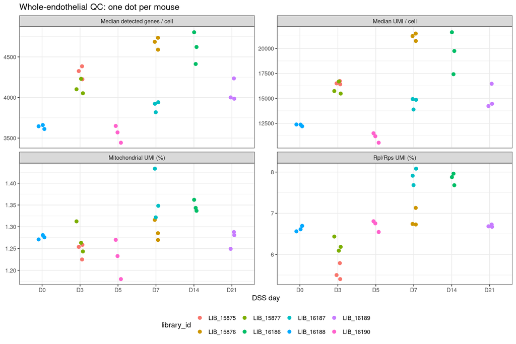

```r
qc_long <- ma %>%
  select(mouse_id,library_id,DSS_day,ribo_fraction_pooled,mt_fraction_pooled,
         median_nUMI,median_nGene) %>%
  mutate(`Rpl/Rps UMI (%)`=100*ribo_fraction_pooled,
         `Mitochondrial UMI (%)`=100*mt_fraction_pooled,
         `Median UMI / cell`=median_nUMI,
         `Median detected genes / cell`=median_nGene) %>%
  select(mouse_id,library_id,DSS_day,`Rpl/Rps UMI (%)`,
         `Mitochondrial UMI (%)`,`Median UMI / cell`,`Median detected genes / cell`) %>%
  pivot_longer(cols=-c(mouse_id,library_id,DSS_day),
               names_to="measure",values_to="value")
ggplot(qc_long,aes(DSS_day,value,color=library_id))+
  geom_point(size=2.4,position=position_jitter(width=.10,height=0))+
  facet_wrap(~measure,scales="free_y",ncol=2)+
  labs(title="Whole-endothelial QC: one dot per mouse",x="DSS day",y=NULL)+
  theme_bw(base_size=12)+theme(legend.position="bottom")
```

```r
z <- ms %>% filter(n_cells>=P$min_cells_mouse_subtype)
cat(sprintf("**Answer.** Across %d mice in %d libraries, Rpl/Rps fractions range from %.2f%% to %.2f%%. ",
  n_distinct(ma$mouse_id),n_distinct(ma$library_id),
  100*min(ma$ribo_fraction_pooled),100*max(ma$ribo_fraction_pooled)))
```

**Answer.** Across 24 mice in 8 libraries, Rpl/Rps fractions range from 5.40% to 8.08%.

```r
for (v in c("median_nUMI","median_nGene","mt_fraction_pooled")) {
  r <- cor(z$ribo_fraction_pooled,z[[v]],method="spearman",use="complete.obs")
  cat(sprintf("Pooled Spearman rho with %s = %.3f. ",v,r))
}
```

Pooled Spearman rho with median_nUMI = 0.117. Pooled Spearman rho with median_nGene = 0.015. Pooled Spearman rho with mt_fraction_pooled = 0.108.

```r
cat("Overall, Rpl/Rps fractions show weak associations with these QC measures.\n")
```

Overall, Rpl/Rps fractions show weak associations with these QC measures.

## 2. Is the ribosomal pattern consistent across endothelial subtypes and same-day libraries?

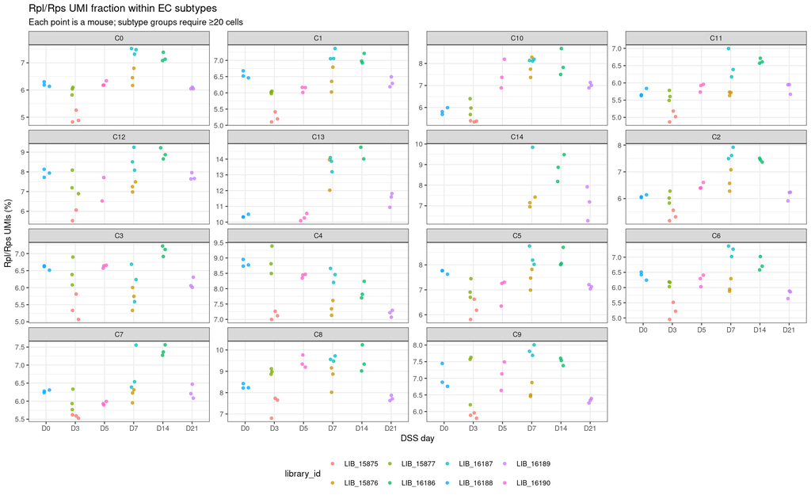

```r
sub <- ms %>% filter(n_cells>=P$min_cells_mouse_subtype) %>%
  mutate(ribo_pct=100*ribo_fraction_pooled)
ggplot(sub,aes(DSS_day,ribo_pct,color=library_id))+
  geom_point(position=position_jitter(width=.12,height=0),size=1.3,alpha=.75)+
  facet_wrap(~EC_subtype,ncol=4,scales="free_y")+
  labs(title="Rpl/Rps UMI fraction within EC subtypes",
       subtitle="Each point is a mouse; subtype groups require ≥20 cells",
       x="DSS day",y="Rpl/Rps UMIs (%)")+
  theme_bw(base_size=10)+theme(legend.position="bottom")
```

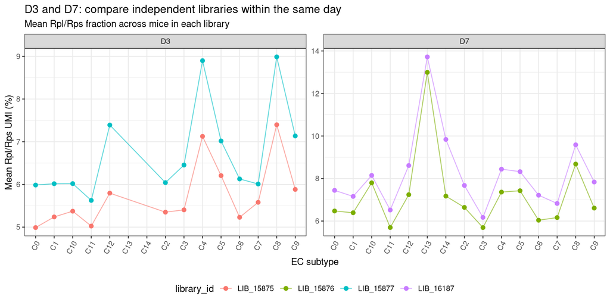

```r
rep <- sub %>% filter(as.character(DSS_day) %in% c("D3","D7")) %>%
  group_by(DSS_day,EC_subtype,library_id) %>%
  summarise(mean_ribo_pct=mean(ribo_pct),n_mice=n(),.groups="drop")
ggplot(rep,aes(EC_subtype,mean_ribo_pct,color=library_id,group=library_id))+
  geom_point(size=2)+geom_line(alpha=.6)+facet_wrap(~DSS_day,scales="free_y")+
  labs(title="D3 and D7: compare independent libraries within the same day",
       subtitle="Mean Rpl/Rps fraction across mice in each library",
       x="EC subtype",y="Mean Rpl/Rps UMI (%)")+
  theme_bw(base_size=11)+theme(axis.text.x=element_text(angle=60,hjust=1),
                              legend.position="bottom")
```

**Answer.** Rpl/Rps fractions show subtype- and day-specific patterns. The D3 and D7 plots compare those patterns across the two libraries collected at each time point.

## 3. Do individual Rpl/Rps genes move together over time?

Instead of showing eight separate dot plots for one subtype, this heatmap summarizes the **direction and size of change across all EC subtypes**. It adapts the gene-coordination plot from v5.

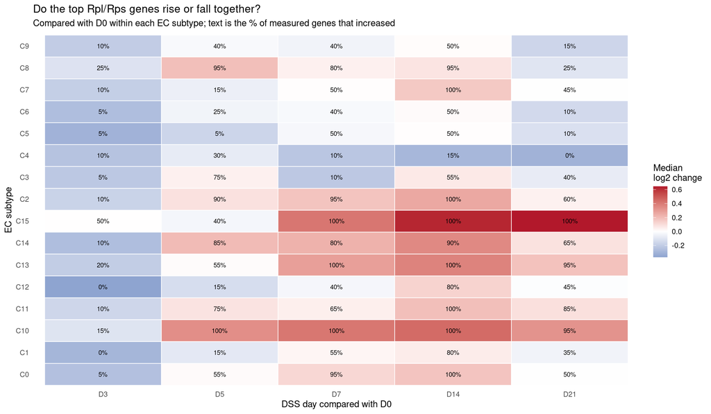

```r
# Existing exported CPM values only. Compare each subtype/day with that subtype's D0 mice.
gene_mouse <- gx %>%
  mutate(CPM=as.numeric(CPM), DSS_day=as.character(DSS_day)) %>%
  filter(is.finite(CPM), CPM>=0) %>%
  group_by(EC_subtype, gene, DSS_day, mouse_id) %>%
  summarise(CPM=mean(CPM),.groups="drop")
gene_day <- gene_mouse %>%
  group_by(EC_subtype,gene,DSS_day) %>%
  summarise(mean_CPM=mean(CPM),n_mice=n_distinct(mouse_id),.groups="drop")
gene_baseline <- gene_day %>% filter(DSS_day=="D0") %>%
  select(EC_subtype,gene,baseline_CPM=mean_CPM)
gene_change <- gene_day %>%
  filter(DSS_day!="D0") %>%
  inner_join(gene_baseline,by=c("EC_subtype","gene")) %>%
  mutate(log2_change=log2((mean_CPM+1)/(baseline_CPM+1)))
gene_coord <- gene_change %>%
  group_by(EC_subtype,DSS_day) %>%
  summarise(median_log2_change=median(log2_change,na.rm=TRUE),
            percent_genes_up=100*mean(log2_change>0,na.rm=TRUE),
            n_genes=n(),.groups="drop") %>%
  filter(n_genes>0) %>%
  mutate(DSS_day=factor(DSS_day,levels=day_levels))
ggplot(gene_coord,aes(DSS_day,EC_subtype,fill=median_log2_change))+
  geom_tile(colour="white",linewidth=.35)+
  geom_text(aes(label=paste0(round(percent_genes_up),"%")),size=2.7)+
  scale_fill_gradient2(low="#2166ac",mid="white",high="#b2182b",midpoint=0)+
  labs(title="Do the top Rpl/Rps genes rise or fall together?",
       subtitle="Compared with D0 within each EC subtype; text is the % of measured genes that increased",
       x="DSS day compared with D0",y="EC subtype",fill="Median\nlog2 change")+
  theme_minimal(base_size=11)+theme(panel.grid=element_blank())
```

**How to read it:** Red means the typical measured Rpl/Rps gene is higher than at D0; blue means lower. A label of **80%** means 80% of the measured genes increased in that subtype/day. If many genes move in the same direction, the pattern is more coordinated than a change in just one gene.

**Measurement:** This plot summarizes relative CPM changes among the top Rpl/Rps genes in the exported dataset.

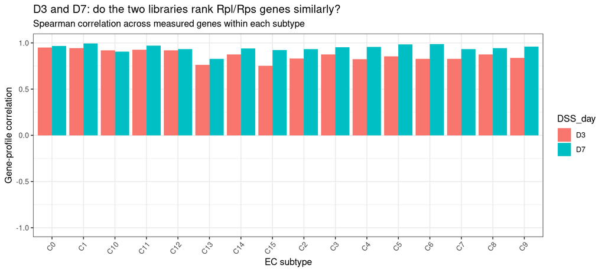

```r
# A second v5-inspired check: do same-day libraries show similar relative gene patterns?
lib_gene <- gene_mouse %>%
  inner_join(mouse_map %>% select(mouse_id,library_id),by="mouse_id") %>%
  filter(DSS_day %in% c("D3","D7")) %>%
  group_by(DSS_day,EC_subtype,library_id,gene) %>%
  summarise(mean_CPM=mean(CPM),.groups="drop")
lib_gene_pairs <- lib_gene %>%
  group_by(DSS_day,EC_subtype,gene) %>%
  arrange(library_id,.by_group=TRUE) %>%
  mutate(library_number=row_number()) %>% ungroup() %>%
  filter(library_number<=2) %>%
  select(DSS_day,EC_subtype,gene,library_number,mean_CPM) %>%
  pivot_wider(names_from=library_number,values_from=mean_CPM,names_prefix="lib_")
lib_agreement <- lib_gene_pairs %>%
  group_by(DSS_day,EC_subtype) %>%
  summarise(n_genes=sum(complete.cases(lib_1,lib_2)),
            rho=if(n_genes[1]>=5) suppressWarnings(cor(lib_1,lib_2,method="spearman",use="complete.obs")) else NA_real_,
            .groups="drop") %>%
  filter(is.finite(rho))
if(nrow(lib_agreement)) {
  print(ggplot(lib_agreement,aes(EC_subtype,rho,fill=DSS_day))+
    geom_col(position="dodge")+coord_cartesian(ylim=c(-1,1))+
    labs(title="D3 and D7: do the two libraries rank Rpl/Rps genes similarly?",
         subtitle="Spearman correlation across measured genes within each subtype",
         x="EC subtype",y="Gene-profile correlation")+
    theme_bw(base_size=11)+theme(axis.text.x=element_text(angle=50,hjust=1)))
} else cat("Not enough paired gene measurements for same-day library comparison.\n")
```

**In simple terms:** A correlation near 1 means that the two libraries have similar relative expression profiles across the measured Rpl/Rps genes.

## 4. Are the same Rpl/Rps genes reused in many pathway results?

The v5 report separates the repeated genes by broad pathway theme. This is more informative than a single bar showing how often each gene appears.

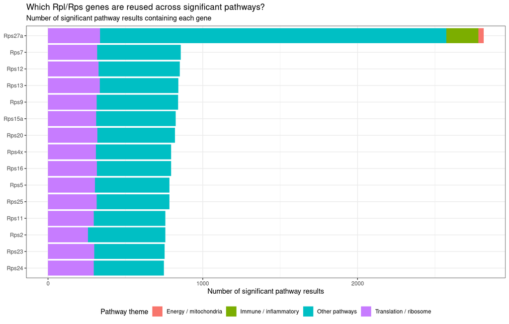

```r
# Each row is a significant pathway result for one subtype and comparison.
# Assign transparent broad labels from pathway names; do not imply independent pathways.
pathway_theme <- function(x) {
  dplyr::case_when(
    grepl("RIBOSOM|TRANSLAT|SRP_DEPENDENT|PEPTIDE_CHAIN|NONSENSE_MEDIATED|RRNA_PROCESS|ELONGATION",x,ignore.case=TRUE) ~ "Translation / ribosome",
    grepl("INTERFERON|INTERLEUKIN|CYTOKINE|CHEMOKINE|INFLAMMAT|IMMUNE|TNF|NFKB|COMPLEMENT|ANTIGEN|TOLL_LIKE|LEUKOCYTE",x,ignore.case=TRUE) ~ "Immune / inflammatory",
    grepl("RESPIRAT|ELECTRON_TRANSPORT|OXIDATIVE|MITOCHONDR|TCA_CYCLE",x,ignore.case=TRUE) ~ "Energy / mitochondria",
    TRUE ~ "Other pathways")
}
reuse <- gs %>%
  mutate(theme=pathway_theme(pathway),
         ribo_genes=ifelse(is.na(ribo_genes),"",ribo_genes)) %>%
  select(database,subtype,contrast,pathway,theme,ribo_genes) %>%
  tidyr::separate_rows(ribo_genes,sep="[,;|]") %>%
  mutate(gene=trimws(ribo_genes)) %>%
  filter(grepl("^Rp[ls]",gene,ignore.case=TRUE),nzchar(gene)) %>%
  distinct(database,subtype,contrast,pathway,theme,gene) %>%
  count(gene,theme,name="pathway_hits")
if(nrow(reuse)) {
  top_reused <- reuse %>% group_by(gene) %>%
    summarise(total=sum(pathway_hits),.groups="drop") %>%
    slice_max(total,n=15,with_ties=FALSE) %>% pull(gene)
  reuse_plot <- reuse %>% filter(gene %in% top_reused) %>%
    mutate(gene=factor(gene,levels=rev(top_reused)))
  print(ggplot(reuse_plot,aes(gene,pathway_hits,fill=theme))+
    geom_col()+coord_flip()+
    labs(title="Which Rpl/Rps genes are reused across significant pathways?",
         subtitle="Number of significant pathway results containing each gene",
         x=NULL,y="Number of significant pathway results",fill="Pathway theme")+
    theme_bw(base_size=11)+theme(legend.position="bottom"))
} else cat("No Rpl/Rps genes could be parsed from the significant leading-edge export.\n")
```

**How to read it:** Longer bars identify Rpl/Rps genes appearing in more significant pathway leading edges. Colors show the biological themes in which each gene appears. Translation-related pathways share many of these genes.

## 5. Do inflammatory pathways have nonribosomal support?

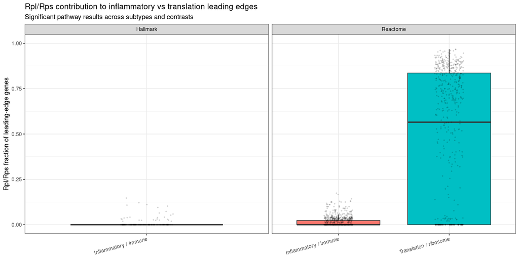

```r
translation_re <- paste(c("RIBOSOM","TRANSLAT","PEPTIDE_CHAIN","PEPTIDE CHAIN",
 "SRP_DEPENDENT","SRP-DEPENDENT","NONSENSE_MEDIATED","NONSENSE-MEDIATED",
 "RRNA_PROCESS","RRNA PROCESS","RIBOSOMAL","INITIATION","ELONGATION"),collapse="|")
inflammation_re <- paste(c("INFLAMMAT","INTERFERON","INTERLEUKIN","CYTOKINE",
 "CHEMOKINE","TNFA","TNF_","TNF ","NFKB","NF_KB","NF-KB","IMMUNE",
 "ANTIGEN","COMPLEMENT","TOLL_LIKE","TOLL-LIKE","JAK_STAT","JAK-STAT",
 "IL6","IL_6","IL-6","IL1","IL_1","IL-1","LEUKOCYTE",
 "NEUTROPHIL","MACROPHAGE","ALLOGRAFT_REJECTION","T_CELL","B_CELL",
 "RESPONSE_TO_BACTER","RESPONSE TO BACTER"),collapse="|")
comparison <- gs %>% mutate(
  trans=grepl(translation_re,pathway,ignore.case=TRUE),
  inflam=grepl(inflammation_re,pathway,ignore.case=TRUE),
  category=case_when(
    trans & !inflam ~ "Translation / ribosome",
    inflam & !trans ~ "Inflammatory / immune",
    TRUE ~ "Other")) %>%
  filter(category!="Other") %>%
  mutate(category=factor(category,
    levels=c("Inflammatory / immune","Translation / ribosome")))
ggplot(comparison,aes(category,ribo_leading_fraction,fill=category))+
  geom_boxplot(outlier.shape=NA)+
  geom_jitter(width=.13,alpha=.12,size=.5)+
  facet_wrap(~database,scales="free_x")+
  scale_y_continuous(limits=c(0,1))+
  labs(title="Rpl/Rps contribution to inflammatory vs translation leading edges",
       subtitle="Significant pathway results across subtypes and contrasts",
       x=NULL,y="Rpl/Rps fraction of leading-edge genes")+
  theme_bw(base_size=11)+theme(legend.position="none",
                              axis.text.x=element_text(angle=15,hjust=1))
```

```r
tab <- comparison %>% group_by(database,category) %>%
  summarise(hits=n(),
            median_ribo_pct=round(100*median(ribo_leading_fraction,na.rm=TRUE),1),
            pct_with_5_nonribo=round(100*mean(n_nonribo>=5,na.rm=TRUE),1),
            .groups="drop")
knitr::kable(tab,col.names=c("Database","Pathway theme","Significant hits",
 "Median Rpl/Rps leading edge (%)","Hits with ≥5 nonribosomal genes (%)"))
```

| Database | Pathway theme | Significant hits | Median Rpl/Rps leading edge (%) | Hits with ≥5 nonribosomal genes (%) |
| --- | --- | --- | --- | --- |
| Hallmark | Inflammatory / immune | 326 | 0.0 | 100.0 |
| Reactome | Inflammatory / immune | 1064 | 0.0 | 98.7 |
| Reactome | Translation / ribosome | 667 | 56.5 | 88.5 |

**Answer.** Rpl/Rps genes are concentrated in translation/ribosome pathways, where they are expected. Inflammatory and immune pathways show low ribosomal contributions, with most leading-edge genes being nonribosomal.

### Additional view: ribosomal contribution across biological themes

This is the broader v5 comparison. **Each dot** is one significant pathway result for one EC subtype and contrast. **Each box** summarizes the Rpl/Rps percentage for that theme. The dashed line marks 50%: results to its right have more ribosomal than nonribosomal genes in their leading edge.

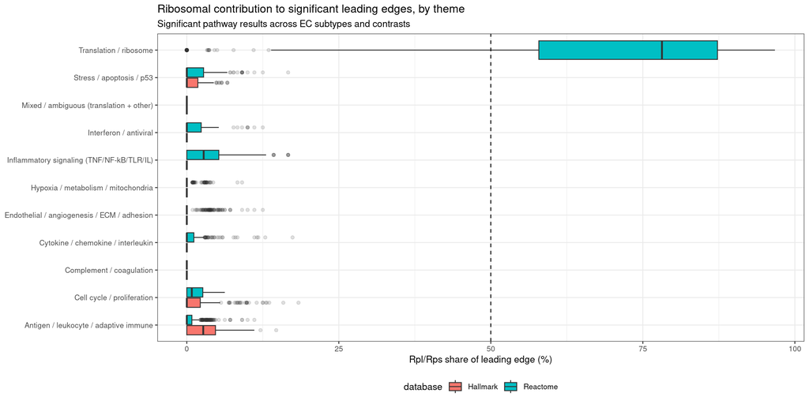

```r
translation_re <- "RIBOSOM|TRANSLATION|PEPTIDE_CHAIN|SRP_DEPENDENT|NONSENSE_MEDIATED|RRNA_PROCESS|SELENOCYSTEINE"
theme_rules <- list(
  "Interferon / antiviral"            = "INTERFERON|ANTIVIRAL|ISG15",
  "Inflammatory signaling (TNF/NF-kB/TLR/IL)" = "INFLAMMAT|TNFA|TNF_|NFKB|NF_KB|TOLL|TLR|IL1_|IL6_|IL_6|JAK_STAT|STAT3",
  "Cytokine / chemokine / interleukin" = "CYTOKINE|CHEMOKINE|INTERLEUKIN|IL2_|IL_2",
  "Complement / coagulation"          = "COMPLEMENT|COAGULATION|PLATELET",
  "Antigen / leukocyte / adaptive immune" = "ANTIGEN|MHC|T_CELL|B_CELL|LYMPHOCYTE|LEUKOCYTE|NEUTROPHIL|MACROPHAGE|ALLOGRAFT|IMMUNE",
  "Endothelial / angiogenesis / ECM / adhesion" = "ANGIOGEN|ENDOTHEL|VASCUL|MATRIX|COLLAGEN|INTEGRIN|ADHESION|EPITHELIAL_MESENCHYMAL|JUNCTION|NOTCH",
  "Hypoxia / metabolism / mitochondria" = "HYPOXIA|GLYCOLYSIS|OXIDATIVE_PHOSPHORYLATION|RESPIRATORY|TCA_CYCLE|FATTY_ACID|MTORC1|MITOCHOND|ELECTRON_TRANSPORT|CHOLESTEROL",
  "Cell cycle / proliferation"        = "E2F|G2M|MITOTIC|CELL_CYCLE|DNA_REPLICATION|MYC_TARGETS",
  "Stress / apoptosis / p53"          = "APOPTOSIS|P53|UNFOLDED|HEAT_SHOCK|ER_STRESS|STRESS|DNA_DAMAGE|AUTOPHAGY")
assign_theme <- function(p) {
  tr <- grepl(translation_re, p)
  hits <- vapply(theme_rules, function(re) grepl(re, p), logical(1))
  if (tr && any(hits)) "Mixed / ambiguous (translation + other)"
  else if (tr) "Translation / ribosome"
  else if (any(hits)) names(theme_rules)[which(hits)[1]]
  else "Other / unclassified"
}
theme_plot_data <- gs %>%
  mutate(path_norm = gsub("[^A-Z0-9]+", "_", toupper(pathway)),
         theme = vapply(path_norm, assign_theme, character(1))) %>%
  filter(theme != "Other / unclassified", is.finite(ribo_leading_fraction)) %>%
  mutate(theme = reorder(theme, ribo_leading_fraction, FUN = median))

ggplot(theme_plot_data, aes(theme, 100 * ribo_leading_fraction, fill = database)) +
  geom_boxplot(outlier.alpha = .15) +
  coord_flip() +
  geom_hline(yintercept = 100 * P$ribo_dominance_threshold, linetype = 2) +
  theme_bw(base_size = 10) +
  theme(legend.position = "bottom") +
  labs(x = NULL, y = "Rpl/Rps share of leading edge (%)",
       title = "Ribosomal contribution to significant leading edges, by theme",
       subtitle = "Significant pathway results across EC subtypes and contrasts")
```

**Simple interpretation:** Reactome translation/ribosome pathways have the highest Rpl/Rps contributions. Inflammatory, immune, endothelial, and metabolic pathway leading edges consist predominantly of nonribosomal genes. The theme labels group pathways by their names.